# Chapter10

Ohood Aljohani

9/28/2021

## Descriptive and Inferential Statistics on Diamonds data set

In This document we will present a quick guide about implementing the basic **descriptive and inferential Statistics on R** . While descriptive statistics is used to describe the data we have ,we use inferential statistics to try to infer from the sample data what the population could look like. We are going to use the diamonds data set , it has 53940 observation but we will use only 1% of the data.

```r
library(tidyverse)
My_data <- read.csv("data/diamonds.csv")
head(My_data)
```

```
##   carat       cut color clarity depth table price    x    y    z
## 1  0.23     Ideal     E     SI2  61.5    55   326 3.95 3.98 2.43
## 2  0.21   Premium     E     SI1  59.8    61   326 3.89 3.84 2.31
## 3  0.23      Good     E     VS1  56.9    65   327 4.05 4.07 2.31
## 4  0.29   Premium     I     VS2  62.4    58   334 4.20 4.23 2.63
## 5  0.31      Good     J     SI2  63.3    58   335 4.34 4.35 2.75
## 6  0.24 Very Good     J    VVS2  62.8    57   336 3.94 3.96 2.48
```

```r
str(My_data)
```

```
## 'data.frame':    53940 obs. of  10 variables:
##  $ carat  : num  0.23 0.21 0.23 0.29 0.31 0.24 0.24 0.26 0.22 0.23 ...
##  $ cut    : chr  "Ideal" "Premium" "Good" "Premium" ...
##  $ color  : chr  "E" "E" "E" "I" ...
##  $ clarity: chr  "SI2" "SI1" "VS1" "VS2" ...
##  $ depth  : num  61.5 59.8 56.9 62.4 63.3 62.8 62.3 61.9 65.1 59.4 ...
##  $ table  : num  55 61 65 58 58 57 57 55 61 61 ...
##  $ price  : int  326 326 327 334 335 336 336 337 337 338 ...
##  $ x      : num  3.95 3.89 4.05 4.2 4.34 3.94 3.95 4.07 3.87 4 ...
##  $ y      : num  3.98 3.84 4.07 4.23 4.35 3.96 3.98 4.11 3.78 4.05 ...
##  $ z      : num  2.43 2.31 2.31 2.63 2.75 2.48 2.47 2.53 2.49 2.39 ...
```

let’s take a look at the data : \

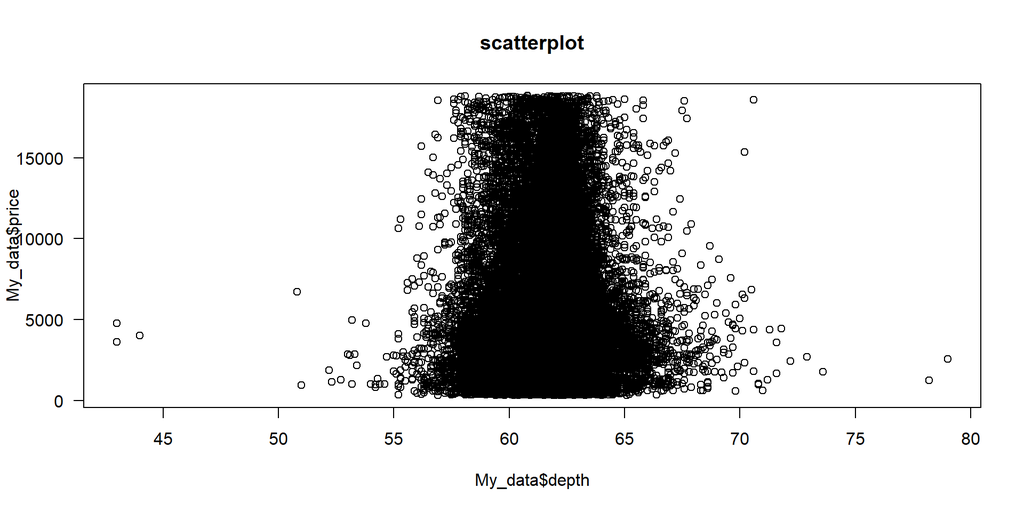

```r
plot(My_data$depth,My_data$price,main = "scatterplot",las=1)
```

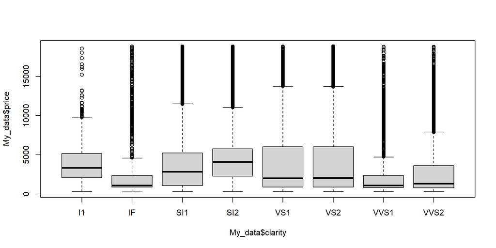

```r
boxplot(My_data$price~My_data$clarity)
```

The Price described by the cut :\

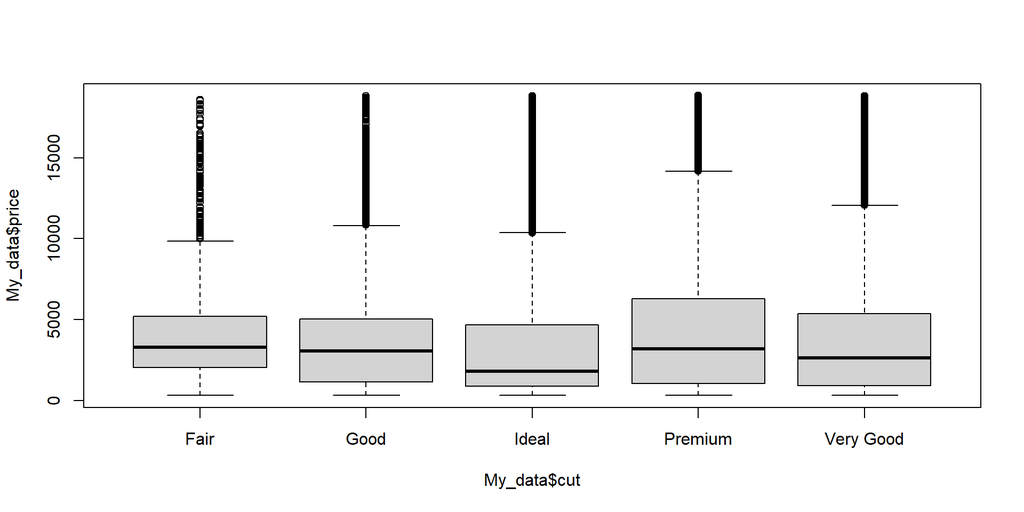

```r
boxplot(My_data$price~My_data$cut)
```

The price described by the color :

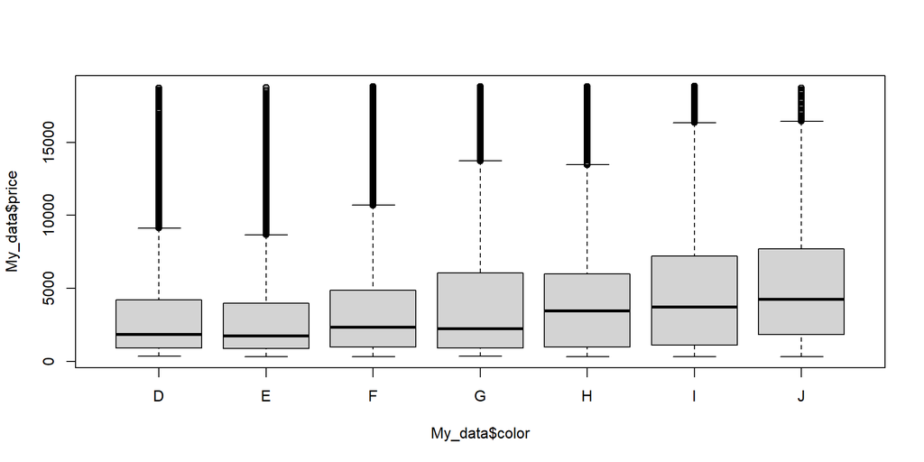

```r
boxplot(My_data$price~My_data$color)
```

Some descriptive Statistics can be done using functions in R such as summary which we will use to find the mean ,Q1,Q3,min,max to find the range : The price range is from 326 to 18823

```r
price_range <- range(My_data$price)
#max(My_data$price)-min(My_data$price)
price_range[2]- price_range[1]
```

```
## [1] 18497
```

```r
summary(My_data)
```

```
##      carat            cut               color             clarity
##  Min.   :0.2000   Length:53940       Length:53940       Length:53940
##  1st Qu.:0.4000   Class :character   Class :character   Class :character
##  Median :0.7000   Mode  :character   Mode  :character   Mode  :character
##  Mean   :0.7979
##  3rd Qu.:1.0400
##  Max.   :5.0100
##      depth           table           price             x
##  Min.   :43.00   Min.   :43.00   Min.   :  326   Min.   : 0.000
##  1st Qu.:61.00   1st Qu.:56.00   1st Qu.:  950   1st Qu.: 4.710
##  Median :61.80   Median :57.00   Median : 2401   Median : 5.700
##  Mean   :61.75   Mean   :57.46   Mean   : 3933   Mean   : 5.731
##  3rd Qu.:62.50   3rd Qu.:59.00   3rd Qu.: 5324   3rd Qu.: 6.540
##  Max.   :79.00   Max.   :95.00   Max.   :18823   Max.   :10.740
##        y                z
##  Min.   : 0.000   Min.   : 0.000
##  1st Qu.: 4.720   1st Qu.: 2.910
##  Median : 5.710   Median : 3.530
##  Mean   : 5.735   Mean   : 3.539
##  3rd Qu.: 6.540   3rd Qu.: 4.040
##  Max.   :58.900   Max.   :31.800
```

```r
by(My_data,My_data$clarity,summary)
```

```
## My_data$clarity: I1
##      carat           cut               color             clarity
##  Min.   :0.300   Length:741         Length:741         Length:741
##  1st Qu.:0.960   Class :character   Class :character   Class :character
##  Median :1.120   Mode  :character   Mode  :character   Mode  :character
##  Mean   :1.284
##  3rd Qu.:1.510
##  Max.   :5.010
##      depth           table          price             x
##  Min.   :55.60   Min.   :52.0   Min.   :  345   Min.   : 4.330
##  1st Qu.:61.10   1st Qu.:56.0   1st Qu.: 2080   1st Qu.: 6.220
##  Median :62.20   Median :58.0   Median : 3344   Median : 6.650
##  Mean   :62.73   Mean   :58.3   Mean   : 3924   Mean   : 6.761
##  3rd Qu.:64.30   3rd Qu.:60.0   3rd Qu.: 5161   3rd Qu.: 7.340
##  Max.   :78.20   Max.   :67.0   Max.   :18531   Max.   :10.740
##        y                z
##  Min.   : 4.290   Min.   :0.000
##  1st Qu.: 6.140   1st Qu.:3.860
##  Median : 6.610   Median :4.110
##  Mean   : 6.709   Mean   :4.208
##  3rd Qu.: 7.280   3rd Qu.:4.600
##  Max.   :10.540   Max.   :6.980
## ------------------------------------------------------------
## My_data$clarity: IF
##      carat            cut               color             clarity
##  Min.   :0.2300   Length:1790        Length:1790        Length:1790
##  1st Qu.:0.3100   Class :character   Class :character   Class :character
##  Median :0.3500   Mode  :character   Mode  :character   Mode  :character
##  Mean   :0.5051
##  3rd Qu.:0.5500
##  Max.   :2.2900
##      depth           table           price             x
##  Min.   :52.30   Min.   :52.00   Min.   :  369   Min.   :3.860
##  1st Qu.:61.00   1st Qu.:55.00   1st Qu.:  895   1st Qu.:4.380
##  Median :61.70   Median :56.00   Median : 1080   Median :4.570
##  Mean   :61.51   Mean   :56.51   Mean   : 2865   Mean   :4.968
##  3rd Qu.:62.10   3rd Qu.:58.00   3rd Qu.: 2388   3rd Qu.:5.280
##  Max.   :65.60   Max.   :65.00   Max.   :18806   Max.   :8.490
##        y               z
##  Min.   :3.880   Min.   :2.390
```

[output cut: 128 more lines]

```
##  Max.   :2.0700
##      depth           table           price               x
##  Min.   :51.00   Min.   :51.00   Min.   :  336.0   Min.   :3.830
##  1st Qu.:61.10   1st Qu.:56.00   1st Qu.:  794.2   1st Qu.:4.390
##  Median :61.80   Median :57.00   Median : 1311.0   Median :4.900
##  Mean   :61.66   Mean   :57.02   Mean   : 3283.7   Mean   :5.218
##  3rd Qu.:62.30   3rd Qu.:58.00   3rd Qu.: 3638.2   3rd Qu.:5.820
##  Max.   :67.60   Max.   :68.00   Max.   :18768.0   Max.   :8.180
##        y               z
##  Min.   :3.860   Min.   :2.060
##  1st Qu.:4.402   1st Qu.:2.710
##  Median :4.900   Median :3.010
##  Mean   :5.232   Mean   :3.221
##  3rd Qu.:5.840   3rd Qu.:3.590
##  Max.   :8.170   Max.   :5.110
```

```r
by(My_data,My_data$cut,summary)
```

```
## My_data$cut: Fair
##      carat           cut               color             clarity
##  Min.   :0.220   Length:1610        Length:1610        Length:1610
##  1st Qu.:0.700   Class :character   Class :character   Class :character
##  Median :1.000   Mode  :character   Mode  :character   Mode  :character
##  Mean   :1.046
##  3rd Qu.:1.200
##  Max.   :5.010
##      depth           table           price             x
##  Min.   :43.00   Min.   :49.00   Min.   :  337   Min.   : 0.000
##  1st Qu.:64.40   1st Qu.:56.00   1st Qu.: 2050   1st Qu.: 5.630
##  Median :65.00   Median :58.00   Median : 3282   Median : 6.175
##  Mean   :64.04   Mean   :59.05   Mean   : 4359   Mean   : 6.247
##  3rd Qu.:65.90   3rd Qu.:61.00   3rd Qu.: 5206   3rd Qu.: 6.700
##  Max.   :79.00   Max.   :95.00   Max.   :18574   Max.   :10.740
##        y                z
##  Min.   : 0.000   Min.   :0.000
##  1st Qu.: 5.570   1st Qu.:3.610
##  Median : 6.100   Median :3.970
##  Mean   : 6.183   Mean   :3.983
##  3rd Qu.: 6.640   3rd Qu.:4.280
##  Max.   :10.540   Max.   :6.980
## ------------------------------------------------------------
## My_data$cut: Good
##      carat            cut               color             clarity
##  Min.   :0.2300   Length:4906        Length:4906        Length:4906
##  1st Qu.:0.5000   Class :character   Class :character   Class :character
##  Median :0.8200   Mode  :character   Mode  :character   Mode  :character
##  Mean   :0.8492
##  3rd Qu.:1.0100
##  Max.   :3.0100
##      depth           table           price             x
##  Min.   :54.30   Min.   :51.00   Min.   :  327   Min.   :0.000
##  1st Qu.:61.30   1st Qu.:56.00   1st Qu.: 1145   1st Qu.:5.020
##  Median :63.40   Median :58.00   Median : 3050   Median :5.980
##  Mean   :62.37   Mean   :58.69   Mean   : 3929   Mean   :5.839
##  3rd Qu.:63.80   3rd Qu.:61.00   3rd Qu.: 5028   3rd Qu.:6.420
##  Max.   :67.00   Max.   :66.00   Max.   :18788   Max.   :9.440
##        y               z
##  Min.   :0.000   Min.   :0.00
```

[output cut: 59 more lines]

```
##  Max.   :4.0000
##      depth           table           price             x
##  Min.   :56.80   Min.   :44.00   Min.   :  336   Min.   : 0.000
##  1st Qu.:60.90   1st Qu.:56.00   1st Qu.:  912   1st Qu.: 4.750
##  Median :62.10   Median :58.00   Median : 2648   Median : 5.740
##  Mean   :61.82   Mean   :57.96   Mean   : 3982   Mean   : 5.741
##  3rd Qu.:62.90   3rd Qu.:59.00   3rd Qu.: 5373   3rd Qu.: 6.470
##  Max.   :64.90   Max.   :66.00   Max.   :18818   Max.   :10.010
##        y              z
##  Min.   :0.00   Min.   : 0.00
##  1st Qu.:4.77   1st Qu.: 2.95
##  Median :5.77   Median : 3.56
##  Mean   :5.77   Mean   : 3.56
##  3rd Qu.:6.51   3rd Qu.: 4.02
##  Max.   :9.94   Max.   :31.80
```

```r
by(My_data,My_data$color,summary)
```

```
## My_data$color: D
##      carat            cut               color             clarity
##  Min.   :0.2000   Length:6775        Length:6775        Length:6775
##  1st Qu.:0.3600   Class :character   Class :character   Class :character
##  Median :0.5300   Mode  :character   Mode  :character   Mode  :character
##  Mean   :0.6578
##  3rd Qu.:0.9050
##  Max.   :3.4000
##      depth          table          price             x               y
##  Min.   :52.2   Min.   :52.0   Min.   :  357   Min.   :0.000   Min.   :0.000
##  1st Qu.:61.0   1st Qu.:56.0   1st Qu.:  911   1st Qu.:4.590   1st Qu.:4.600
##  Median :61.8   Median :57.0   Median : 1838   Median :5.230   Median :5.240
##  Mean   :61.7   Mean   :57.4   Mean   : 3170   Mean   :5.417   Mean   :5.421
##  3rd Qu.:62.5   3rd Qu.:59.0   3rd Qu.: 4214   3rd Qu.:6.180   3rd Qu.:6.180
##  Max.   :71.6   Max.   :73.0   Max.   :18693   Max.   :9.420   Max.   :9.340
##        z
##  Min.   :0.000
##  1st Qu.:2.820
##  Median :3.220
##  Mean   :3.343
##  3rd Qu.:3.840
##  Max.   :6.270
## ------------------------------------------------------------
## My_data$color: E
##      carat            cut               color             clarity
##  Min.   :0.2000   Length:9797        Length:9797        Length:9797
##  1st Qu.:0.3600   Class :character   Class :character   Class :character
##  Median :0.5300   Mode  :character   Mode  :character   Mode  :character
##  Mean   :0.6579
##  3rd Qu.:0.9000
##  Max.   :3.0500
##      depth           table           price             x
##  Min.   :51.00   Min.   :44.00   Min.   :  326   Min.   :3.740
##  1st Qu.:60.90   1st Qu.:56.00   1st Qu.:  882   1st Qu.:4.570
##  Median :61.80   Median :57.00   Median : 1739   Median :5.230
##  Mean   :61.66   Mean   :57.49   Mean   : 3077   Mean   :5.412
##  3rd Qu.:62.50   3rd Qu.:59.00   3rd Qu.: 4003   3rd Qu.:6.180
##  Max.   :79.00   Max.   :73.00   Max.   :18731   Max.   :9.260
##        y                z
##  Min.   : 3.710   Min.   : 2.060
```

[output cut: 105 more lines]

```
##  Max.   :5.010
##      depth           table           price             x
##  Min.   :43.00   Min.   :51.60   Min.   :  335   Min.   : 3.930
##  1st Qu.:61.20   1st Qu.:56.00   1st Qu.: 1860   1st Qu.: 5.700
##  Median :62.00   Median :58.00   Median : 4234   Median : 6.640
##  Mean   :61.89   Mean   :57.81   Mean   : 5324   Mean   : 6.519
##  3rd Qu.:62.70   3rd Qu.:59.00   3rd Qu.: 7695   3rd Qu.: 7.380
##  Max.   :73.60   Max.   :68.00   Max.   :18710   Max.   :10.740
##        y                z
##  Min.   : 3.900   Min.   :2.460
##  1st Qu.: 5.718   1st Qu.:3.530
##  Median : 6.630   Median :4.110
##  Mean   : 6.518   Mean   :4.033
##  3rd Qu.: 7.380   3rd Qu.:4.580
##  Max.   :10.540   Max.   :6.980
```

```r
glimpse(My_data)
```

```
## Rows: 53,940
## Columns: 10
## $ carat   <dbl> 0.23, 0.21, 0.23, 0.29, 0.31, 0.24, 0.24, 0.26, 0.22, 0.23, 0.~
## $ cut     <chr> "Ideal", "Premium", "Good", "Premium", "Good", "Very Good", "V~
## $ color   <chr> "E", "E", "E", "I", "J", "J", "I", "H", "E", "H", "J", "J", "F~
## $ clarity <chr> "SI2", "SI1", "VS1", "VS2", "SI2", "VVS2", "VVS1", "SI1", "VS2~
## $ depth   <dbl> 61.5, 59.8, 56.9, 62.4, 63.3, 62.8, 62.3, 61.9, 65.1, 59.4, 64~
## $ table   <dbl> 55, 61, 65, 58, 58, 57, 57, 55, 61, 61, 55, 56, 61, 54, 62, 58~
## $ price   <int> 326, 326, 327, 334, 335, 336, 336, 337, 337, 338, 339, 340, 34~
## $ x       <dbl> 3.95, 3.89, 4.05, 4.20, 4.34, 3.94, 3.95, 4.07, 3.87, 4.00, 4.~
## $ y       <dbl> 3.98, 3.84, 4.07, 4.23, 4.35, 3.96, 3.98, 4.11, 3.78, 4.05, 4.~
## $ z       <dbl> 2.43, 2.31, 2.31, 2.63, 2.75, 2.48, 2.47, 2.53, 2.49, 2.39, 2.~
```

To find the median using Median function or Quantile,We can use Quantail to find Q1,Q2,Q 3

```r
median(My_data$price)
```

```
## [1] 2401
```

```r
quantile(My_data$price,0.5)#Q2
```

```
##  50%
## 2401
```

```r
quantile(My_data$price,0.25)#Q1
```

```
## 25%
## 950
```

```r
quantile(My_data$price,0.75)#Q3
```

```
##     75%
## 5324.25
```

The difference between the first and third quartile can be computed with the IQR() function:

```r
IQR(My_data$price)
```

```
## [1] 4374.25
```

The Standard deviation and the Variance can be computed using sd and var functions :

```r
sd(My_data$price)
```

```
## [1] 3989.44
```

```r
var(My_data$price)
```

```
## [1] 15915629
```

```r
first_sample <- sample_frac(My_data['price'], size = 0.01)

second_sample <-sample_frac(My_data['price'], size = 0.01)

summary(first_sample)
```

```
##      price
##  Min.   :  376.0
##  1st Qu.:  914.5
##  Median : 2394.0
##  Mean   : 3923.6
##  3rd Qu.: 5234.0
##  Max.   :18757.0
```

```r
summary(second_sample)
```

```
##      price
##  Min.   :  353.0
##  1st Qu.:  968.5
##  Median : 2443.0
##  Mean   : 3923.7
##  3rd Qu.: 5419.5
##  Max.   :18615.0
```

Now convert them to lists :

```r
sample1 <- as.list(first_sample)

sample2 <- as.list(second_sample)
```

We can run the same commend to get a close look at the first sample :

```r
typeof(sample1$price)
```

```
## [1] "integer"
```

```r
class(sample1)
```

```
## [1] "list"
```

```r
median(sample1$price)
```

```
## [1] 2394
```

```r
quantile(sample1$price,0.5)#Q2
```

```
##  50%
## 2394
```

```r
quantile(sample1$price,0.25)#Q1
```

```
##   25%
## 914.5
```

```r
quantile(sample1$price,0.75)#Q3
```

```
##  75%
## 5234
```

```r
IQR(sample1$price)
```

```
## [1] 4319.5
```

```r
sd(sample1$price)
```

```
## [1] 4041.211
```

```r
var(sample1$price)
```

```
## [1] 16331384
```

Same for sample 2 :

```r
typeof(sample2$price)
```

```
## [1] "integer"
```

```r
class(sample2)
```

```
## [1] "list"
```

```r
median(sample2$price)
```

```
## [1] 2443
```

```r
quantile(sample2$price,0.5)#Q2
```

```
##  50%
## 2443
```

```r
quantile(sample2$price,0.25)#Q1
```

```
##   25%
## 968.5
```

```r
quantile(sample2$price,0.75)#Q3
```

```
##    75%
## 5419.5
```

```r
IQR(sample2$price)
```

```
## [1] 4451
```

```r
sd(sample2$price)
```

```
## [1] 3943.601
```

```r
var(sample2$price)
```

```
## [1] 15551989
```

The mean (X1 -bar)of sample 1 :

```r
mean(sample1$price)
```

```
## [1] 3923.609
```

```r
t.test(sample1$price,mu=5000,alternative = "less",conf.level = 0.95)
```

```
##
##  One Sample t-test
##
## data:  sample1$price
## t = -6.1838, df = 538, p-value = 6.195e-10
## alternative hypothesis: true mean is less than 5000
## 95 percent confidence interval:
##      -Inf 4210.418
## sample estimates:
## mean of x
##  3923.609
```

Now let’s test the **H0** on sample 2 :

```r
t.test(sample2$price,mu=5000,alternative = "less",conf.level = 0.95)
```

```
##
##  One Sample t-test
##
## data:  sample2$price
## t = -6.336, df = 538, p-value = 2.493e-10
## alternative hypothesis: true mean is less than 5000
## 95 percent confidence interval:
##      -Inf 4203.624
## sample estimates:
## mean of x
##  3923.742
```

**Two sided test :**

```r
t.test(sample1$price,mu=5000,alternative = "two.sided",conf.level = 0.95)
```

```
##
##  One Sample t-test
##
## data:  sample1$price
## t = -6.1838, df = 538, p-value = 1.239e-09
## alternative hypothesis: true mean is not equal to 5000
## 95 percent confidence interval:
##  3581.674 4265.543
## sample estimates:
## mean of x
##  3923.609
```

**Two sided on sample 2 :**

```r
t.test(sample2$price,mu=5000,alternative = "two.sided",conf.level = 0.95)
```

```
##
##  One Sample t-test
##
## data:  sample2$price
## t = -6.336, df = 538, p-value = 4.987e-10
## alternative hypothesis: true mean is not equal to 5000
## 95 percent confidence interval:
##  3590.066 4257.418
## sample estimates:
## mean of x
##  3923.742
```

**Aov :** **Extra :**

```r
cor.test(My_data$depth,My_data$price,method = "pearson")
```

```
##
##  Pearson's product-moment correlation
##
## data:  My_data$depth and My_data$price
## t = -2.473, df = 53938, p-value = 0.0134
## alternative hypothesis: true correlation is not equal to 0
## 95 percent confidence interval:
##  -0.019084756 -0.002208537
## sample estimates:
##        cor
## -0.0106474
```

```r
aov(My_data$price~My_data$clarity)
```

```
## Call:
##    aov(formula = My_data$price ~ My_data$clarity)
##
## Terms:
##                 My_data$clarity    Residuals
## Sum of Squares      23307802881 835165332636
## Deg. of Freedom               7        53932
##
## Residual standard error: 3935.165
## Estimated effects may be unbalanced
```

```r
summary(aov(My_data$price~My_data$clarity))
```

```
##                    Df    Sum Sq   Mean Sq F value Pr(>F)
## My_data$clarity     7 2.331e+10 3.330e+09     215 <2e-16 ***
## Residuals       53932 8.352e+11 1.549e+07
## ---
## Signif. codes:  0 '***' 0.001 '**' 0.01 '*' 0.05 '.' 0.1 ' ' 1
```

```r
m<-lm(My_data$depth~My_data$price)                 #x=depth,y=price
summary(m)
```

```
##
## Call:
## lm(formula = My_data$depth ~ My_data$price)
##
## Residuals:
##      Min       1Q   Median       3Q      Max
## -18.7505  -0.7217   0.0784   0.7569  17.2454
##
## Coefficients:
##                 Estimate Std. Error  t value Pr(>|t|)
## (Intercept)    6.176e+01  8.661e-03 7130.977   <2e-16 ***
## My_data$price -3.824e-06  1.546e-06   -2.473   0.0134 *
## ---
## Signif. codes:  0 '***' 0.001 '**' 0.01 '*' 0.05 '.' 0.1 ' ' 1
##
## Residual standard error: 1.433 on 53938 degrees of freedom
## Multiple R-squared:  0.0001134,  Adjusted R-squared:  9.483e-05
## F-statistic: 6.115 on 1 and 53938 DF,  p-value: 0.0134
```

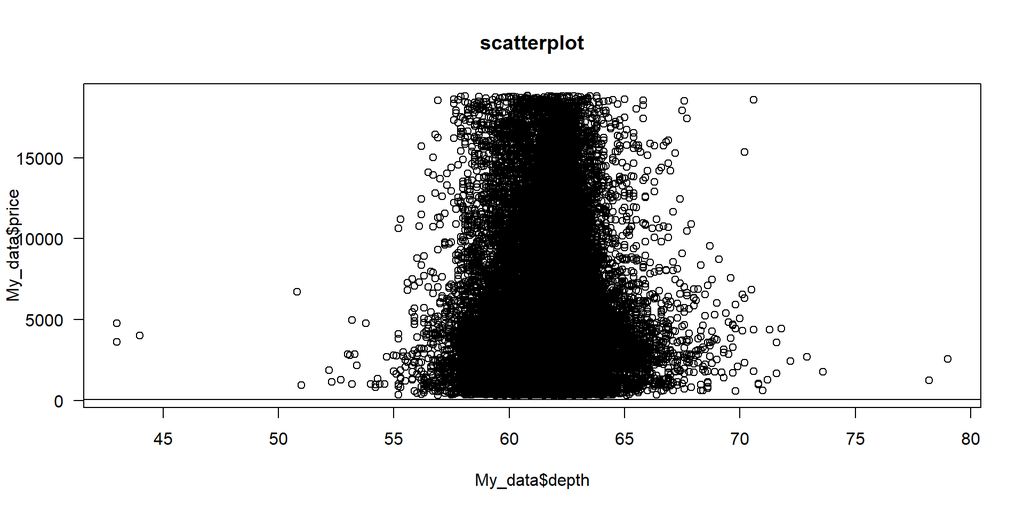

```r
plot(My_data$depth,My_data$price,main = "scatterplot",las=1)
abline(m)
```

anova:

```r
anova(m)
```

```
## Analysis of Variance Table
##
## Response: My_data$depth
##                  Df Sum Sq Mean Sq F value Pr(>F)
## My_data$price     1     13 12.5503  6.1155 0.0134 *
## Residuals     53938 110692  2.0522
## ---
## Signif. codes:  0 '***' 0.001 '**' 0.01 '*' 0.05 '.' 0.1 ' ' 1
```

**The End : I hope this was helpful.**